# Project Files Structure - 001

Author

Ordoñez Silva, Yonel Jr.

# I. Introducción

Este documento describe en detalle **cada capa, componente, carpeta y archivo** de la arquitectura basada en Clean Architecture + enfoque modular + multi-tenant.

# II. Marco Teórico

## 2.1. Modelo C4 o Diagrama C4

Es un conjunto de cuatro diagramas jerárquicos (Context, Contenedores, Componentes y Código) diseñado para representar la arquitectura de software, actuando como un mapa con diferentes niveles de detalle.

# III. Visión General

```
InterfaceAdapters → Application → Domain
                     ↑
               Infrastructure
```

- **Domain**: reglas del negocio
- **Application**: orquestación (casos de uso)
- **InterfaceAdapters**: entrada/salida (HTTP, UI)
- **Infrastructure**: implementación técnica

### 3.1. Diagrama C4 - General y Backend

[figure not shown]

Diagrama C4 - General

[figure not shown]

Diagrama C4 - Backend

### 3.2. Diagrama de Despliegue

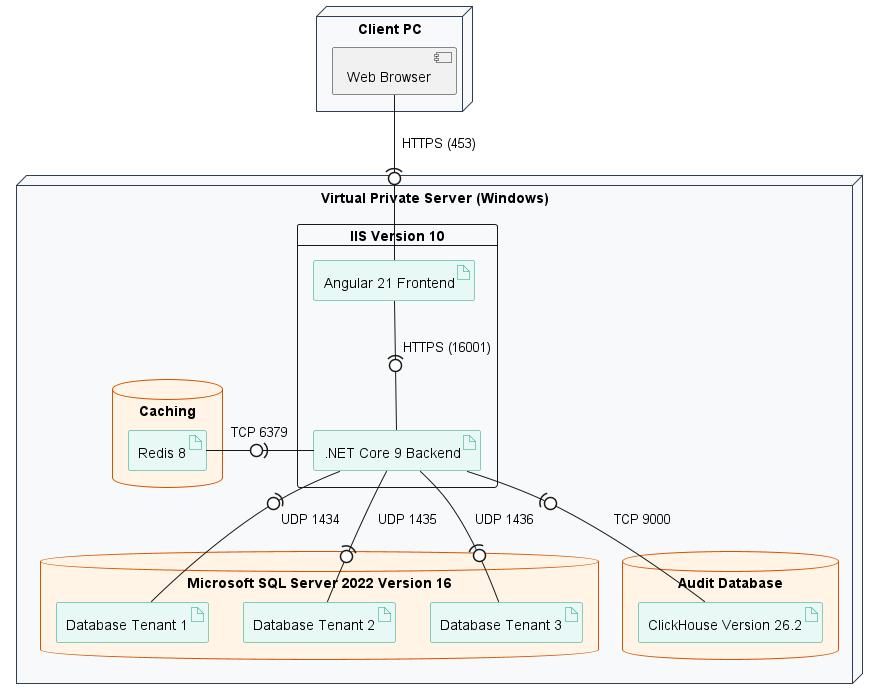

Diagrama de Despliegue

# IV. `Domain` Layer

```bash
Domain/
 ├── Entities/
 │     ├── Product.cs
 │     ├── Animal.cs
 │     ├── MilkRecord.cs
 │     ├── ReproductionEvent.cs
 │     └── AuditEntry.cs
 │
 ├── ValueObjects/
 │     ├── AnimalId.cs
 │     ├── Weight.cs
 │     └── MilkQuantity.cs
 │
 ├── Enums/
 │     ├── AnimalStatus.cs
 │     └── ReproductionType.cs
 │
 ├── Rules/
 │     └── BusinessRule.cs
 │
 ├── Exceptions/
 │     └── DomainException.cs
 │
 └── Services/
       └── (opcional: lógica compleja de dominio)
```

## Diagrama C4

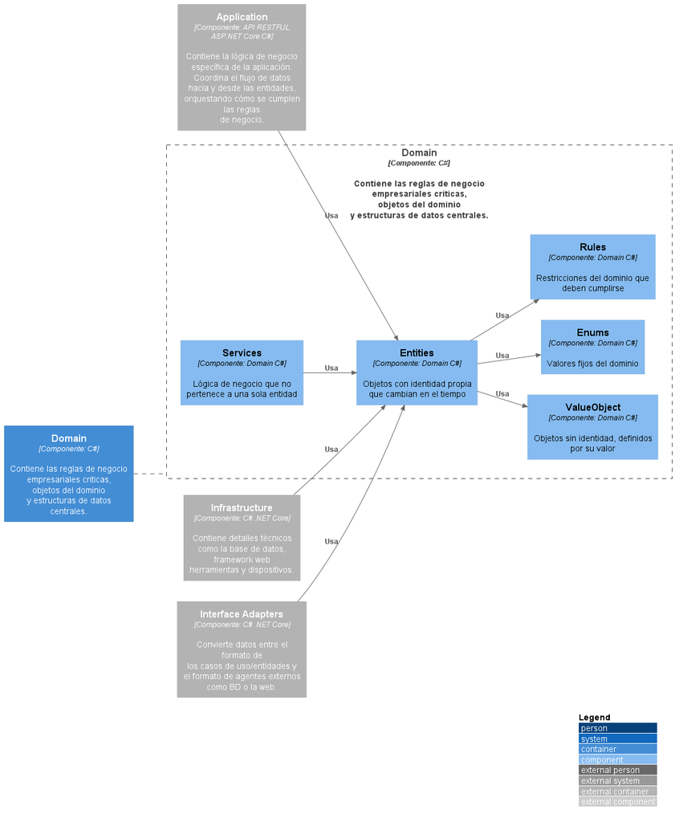

Diagrama C4 - Domain

## Análisis de Cada Componente

### `Exceptions/`

#### `DomainException.cs`

```csharp
namespace Domain.Exceptions;

// Base para errores de negocio
public class DomainException : Exception
{
    public DomainException(string message) : base(message) { }
}
```

### `ValueObjects/`

#### `AnimalId.cs`

```csharp
namespace Domain.ValueObjects;

public class AnimalId
{
    public Guid Value { get; }

    public AnimalId(Guid value)
    {
        if (value == Guid.Empty)
            throw new ArgumentException("Id inválido");

        Value = value;
    }
}
```

#### `AnimalName.cs`

```csharp
using Domain.Exceptions;

namespace Domain.ValueObjects;

public class AnimalName
{
    public string Value { get; }

    public AnimalName(string value)
    {
        if (string.IsNullOrWhiteSpace(value))
            throw new DomainException("El nombre es obligatorio");

        if (value.Length < 3)
            throw new DomainException("El nombre es demasiado corto");

        Value = value;
    }
}
```

### `Enum/`

#### `AnimalStatus.cs`

```csharp
namespace Domain.Enums;

public enum AnimalStatus
{
    Active,
    Inactive,
    Sold
}
```

### `Rules`

#### `AnimalRules.cs`

```csharp
using Domain.Exceptions;

namespace Domain.Rules;

public static class AnimalRules
{
    public static void ValidateBirthDate(DateTime birthDate)
    {
        if (birthDate > DateTime.UtcNow)
            throw new DomainException("La fecha de nacimiento no puede ser futura");
    }
}
```

### `Entities/`

#### `Animal.cs`

```csharp
using Domain.ValueObjects;
using Domain.Enums;
using Domain.Rules;

namespace Domain.Entities;

public class Animal
{
    public Guid Id { get; private set; }
    public string Name { get; private set; }
    public DateTime BirthDate { get; private set; }
    public DateTime CreatedAt { get; private set; }
    public string? CreatedBy { get; private set; }
    public AnimalStatus Status { get; private set; }

    // Constructor privado → obliga a usar métodos controlados
    private Animal() { }

    // Factory method (RECOMENDADO)
    public static Animal Create(
        AnimalId id,
        AnimalName name,
        DateTime birthDate,
        DateTime createdAt,
        string? createdBy)
    {
        // Reglas de dominio
        AnimalRules.ValidateBirthDate(birthDate);

        return new Animal
        {
            Id = id.Value,
            Name = name.Value,
            BirthDate = birthDate,
            CreatedAt = createdAt,
            CreatedBy = createdBy,
            Status = AnimalStatus.Active
        };
    }

    // Comportamiento (NO setters públicos)
    public void Deactivate()
    {
        if (Status == AnimalStatus.Inactive)
            throw new Exception("El animal ya está inactivo");

        Status = AnimalStatus.Inactive;
    }
}
```

# V. `Application` Layer

```bash
Application/
│
├── Common/
│   ├── Gateway/
│   │   ├── Context/
│   │   │   ├── IRequestContext.cs
│   │   │   └── ITenantContext.cs
│   │   │
│   │   ├── Caching/
│   │   │   └── IAppCacheService.cs
│   │   │
│   │   ├── Configuration/
│   │   │   └── IConfigurationService.cs
│   │   │
│   │   ├── Features/
│   │   │   └── IFeatureService.cs
│   │   │
│   │   ├── Rules/
│   │   │   └── IRuleEngineService.cs
│   │   │
│   │   ├── Identity/
│   │   │   └── ICurrentUserService.cs
│   │   │
│   │   ├── Repositories/
│   │   │   └── IAnimalRepository.cs
│   │   │
│   │   └── Time/
│   │       └── IDateTimeProvider.cs
│   │
│   ├── Behaviors/
│   ├── Exceptions/
│   └── Models/
│
├── Modules/
│   │
│   ├── Animals/
│   │   ├── UseCases/
│   │   │   └── CreateAnimal/
│   │   │       ├── Ports/
│   │   │       │   ├── ICreateAnimalInputPort.cs
│   │   │       │   └── ICreateAnimalOutputPort.cs
│   │   │       │
│   │   │       ├── CreateAnimalInteractor.cs
│   │   │       ├── CreateAnimalCommand.cs
│   │   │       ├── CreateAnimalOutput.cs
│   │   │       └── CreateAnimalValidator.cs
│   │   │
│   │   └── DTOs/
│   │
│   ├── Reproduction/
│   │   ├── UseCases/
│   │   ├── Interfaces/
│   │   │   └── IReproductionRepository.cs
│   │
│   ├── Production/
│   │   ├── UseCases/
│   │   ├── Interfaces/
│   │   │   └── IProductionRepository.cs
│   │
│   └── Health/
│       ├── UseCases/
│       ├── Interfaces/
│           └── IHealthRepository.cs
│
└── DependencyInjection.cs
```

## Diagrama C4

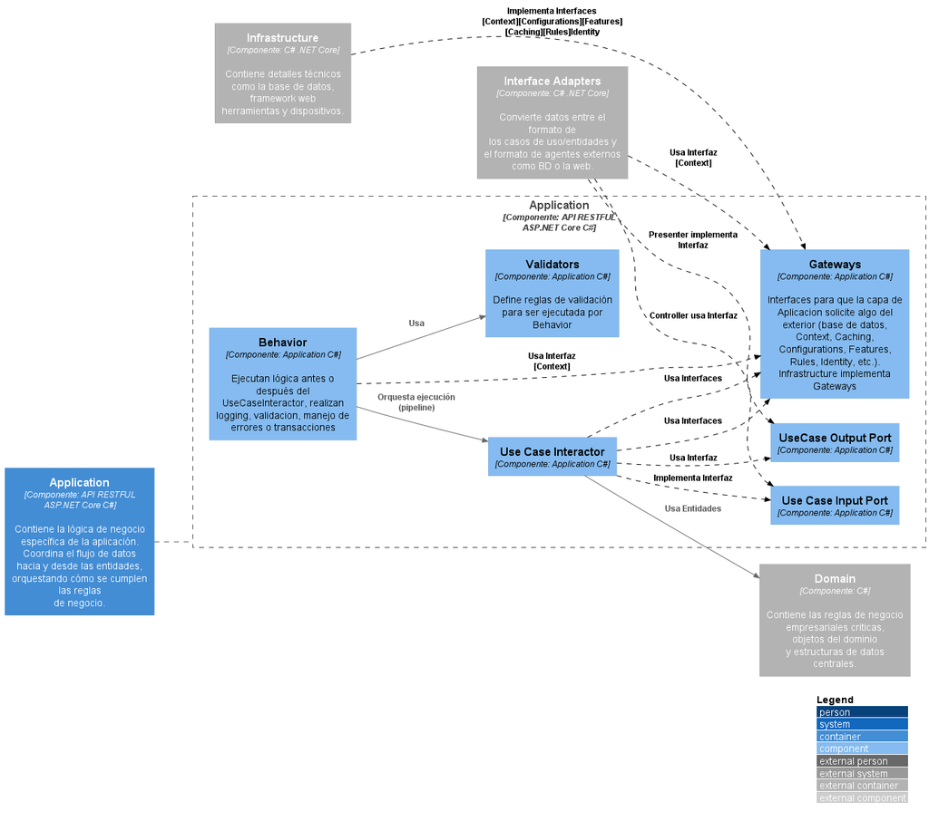

Diagrama C4 - Application

## Análisis de Cada Componente

### `Common/`

#### `Gateway/`

##### `Context/`

###### `ITenantContext.cs`

```csharp
namespace Application.Common.Gateway.Context;

public interface ITenantContext
{
    Guid TenantId { get; }
    string DatabaseName { get; }
}
```

###### `IRequestContext.cs`

```csharp
namespace Application.Common.Gateway.Context;

public interface IRequestContext
{
    string? UserId { get; }
    string? UserEmail { get; }
    string? CorrelationId { get; }
    string? Path { get; }
}
```

##### `Caching/`

###### `IAppCacheService.cs`

```csharp
namespace Application.Common.Gateway.Caching;

// Abstracción de cache (NO depende de IMemoryCache)
public interface IAppCacheService
{
    Task<T> GetOrCreateAsync<T>(
        string key,
        Func<Task<T>> factory,
        TimeSpan expiration);
}
```

##### `Configuration/`

###### `IConfigurationService.cs`

```csharp
namespace Application.Common.Gateway.Configuration;

public interface IConfigurationService
{
    Task<T?> GetValueAsync<T>(string key);
}
```

##### `Features/`

###### `IFeatureService.cs`

```csharp
namespace Application.Common.Gateway.Features;

public interface IFeatureService
{
    Task<bool> IsEnabledAsync(string feature);
}
```

##### `Rules/`

###### `IRuleEngineService.cs`

```csharp
namespace Application.Common.Gateway.Rules;

public interface IRuleEngineService
{
    Task<bool> EvaluateAsync(string rule, object input);
}
```

##### `Identity/`

###### `ICurrentUserService.cs`

```csharp
namespace Application.Common.Gateway.Identity;

public interface ICurrentUserService
{
    string? UserId { get; }
}
```

##### `Repositories/`

###### `IAnimalRepository.cs`

```csharp
using Domain.Entities;

namespace Application.Common.Gateway.Repositories;

public interface IAnimalRepository
{
    Task AddAsync(Animal animal);
}
```

##### `Time/`

Permite abstraer el tiempo.

###### `IDateTimeProvider.cs`

```csharp
namespace Application.Common.Gateway.Time;

public interface IDateTimeProvider
{
    DateTime UtcNow { get; }
}
```

#### `Behaviors/`

Los `Behaviors` son un pipeline alrededor del `UseCase`, parecidos a los `Middlewares` en la capa de `InterfaceAdapters`. Se pueden llamar directamente antes de una request o colocar un pipeline para llamar al `Behavior` y justo después de su lógica llamar al `UseCaseInteractor`.

##### `IPipelineBehavior.cs`

```csharp
namespace Application.Common.Behaviors;

public interface IPipelineBehavior<TRequest>
{
    Task Handle(TRequest request, Func<Task> next);
}
```

##### `ValidationBehavior.cs`

```csharp
namespace Application.Common.Behaviors;

public class ValidationBehavior<TRequest> : IPipelineBehavior<TRequest>
{
    private readonly IEnumerable<IValidator<TRequest>> _validators;

    public ValidationBehavior(IEnumerable<IValidator<TRequest>> validators)
    {
        _validators = validators;
    }

    public async Task Handle(TRequest request, Func<Task> next)
    {
        foreach (var validator in _validators)
        {
            validator.Validate(request);
        }

        await next();
    }
}
```

##### `LoggingBehavior.cs`

```csharp
namespace Application.Common.Behaviors;

public class LoggingBehavior<TRequest> : IPipelineBehavior<TRequest>
{
    public async Task Handle(TRequest request, Func<Task> next)
    {
        Console.WriteLine($"[LOG] Handling {typeof(TRequest).Name}");

        await next();

        Console.WriteLine($"[LOG] Completed {typeof(TRequest).Name}");
    }
}
```

#### `BusinessException.cs`

```csharp
namespace Application.Common.Exceptions;

public class BusinessException : Exception
{
    public BusinessException(string message) : base(message) { }
}


// Uso en UseCaseInteractor
if (!await _features.IsEnabledAsync("animals.create"))
    throw new BusinessException("Feature deshabilitada");
```

#### `Models/`

Aquí van modelos compartidos entre `UseCases` y estructuras complejas (filtros, paginación, etc.).

##### `PaginationModel.cs`

```csharp
public class PaginationModel
{
    public int Page { get; set; }
    public int PageSize { get; set; }
}
```

### `Modules/`

#### `Animals/UseCases/CreateAnimal`

##### `CreateAnimalCommand.cs`

Este es un DTO para mapear la solicitud del usuario.

```csharp
namespace Application.Modules.Animals.UseCases.CreateAnimal;

public class CreateAnimalCommand
{
    public string Name { get; set; } = default!;
    public DateTime BirthDate { get; set; }
}
```

##### `CreateAnimalOutput.cs`

Este es otro DTO pero para mapear el response hacia el usuario.

```csharp
namespace Application.Modules.Animals.UseCases.CreateAnimal;

public class CreateAnimalOutput
{
    public Guid Id { get; set; }
    public string Name { get; set; } = default!;
}
```

##### `ICreateAnimalInputPort.cs`

```csharp
namespace Application.Modules.Animals.UseCases.CreateAnimal;

public interface ICreateAnimalInputPort
{
    Task Handle(CreateAnimalCommand command);
}
```

##### `ICreateAnimalOutputPort.cs`

```csharp
public interface ICreateAnimalOutputPort
{
    Task Ok(CreateAnimalOutput output);
}
```

##### `CreateAnimalInteractor.cs`

```csharp
using Domain.Entities;
using Application.Common.Exceptions;
using Application.Modules.Animals.Interfaces;
using Application.Common.Gateway.Features;
using Application.Common.Gateway.Configuration;
using Application.Common.Gateway.Rules;
using Application.Common.Gateway.Identity;
using Application.Common.Gateway.Time;
using Application.Common.Gateway.Caching;
using Application.Common.Gateway.Context;

namespace Application.Modules.Animals.UseCases.CreateAnimal;

public class CreateAnimalInteractor : ICreateAnimalInputPort
{
    private readonly IAnimalRepository _repo;
    private readonly ICreateAnimalOutputPort _output;
    private readonly IFeatureService _features;
    private readonly IConfigurationService _config;
    private readonly IRuleEngineService _rules;
    private readonly ICurrentUserService _user;
    private readonly IDateTimeProvider _time;
    private readonly IAppCacheService _cache;
    private readonly ITenantContext _tenant;

    public CreateAnimalInteractor(
        IAnimalRepository repo,
        ICreateAnimalOutputPort output,
        IFeatureService features,
        IConfigurationService config,
        IRuleEngineService rules,
        ICurrentUserService user,
        IDateTimeProvider time,
        IAppCacheService cache,
        ITenantContext tenant)
    {
        _repo = repo;
        _output = output;
        _features = features;
        _config = config;
        _rules = rules;
        _user = user;
        _time = time;
        _cache = cache;
        _tenant = tenant;
    }

    public async Task Handle(CreateAnimalCommand cmd)
    {
        // Logging contextual
        Console.WriteLine($"User: {_request.UserId}");
        Console.WriteLine($"Path: {_request.Path}");
        Console.WriteLine($"CorrelationId: {_request.CorrelationId}");

        // 1. Feature
        if (!await _features.IsEnabledAsync("animals.create"))
            throw new BusinessException("Feature deshabilitada");

        // 2. Obtener tenant actual
        var tenantId = _tenant.TenantId;

        // 3. Usar cache POR TENANT
        var minNameLength = await _cache.GetOrCreateAsync(
            $"tenant:{tenantId}:config:minName",
            async () => await _config.GetValueAsync<int>("animal.name.min"),
            TimeSpan.FromMinutes(5)
        );

        // 4. Config (con cache)
        var minNameLength = await _cache.GetOrCreateAsync(
            $"config:minName:{_tenant.TenantId}",
            async () => await _config.GetValueAsync<int>("animal.name.min"),
            TimeSpan.FromMinutes(5)
        );

        if (cmd.Name.Length < minNameLength)
            throw new BusinessException("Nombre inválido");

        // 5. Rules
        var isValid = await _rules.EvaluateAsync(
            "animal.creation.allowed",
            new { cmd.Name });

        if (!isValid)
            throw new BusinessException("Regla no cumplida");

        // 6. Crear entidad
        var animal = new Animal(
            Guid.NewGuid(),
            cmd.Name,
            cmd.BirthDate,
            _time.UtcNow,          // usando TimeProvider
            _user.UserId           // usando identidad
        );

        // 7. Persistencia
        await _repo.AddAsync(animal);

        // 8. Output
        await _output.Ok(new CreateAnimalOutput
        {
            Id = animal.Id,
            Name = animal.Name
        });
    }
}
```

##### `CreateAnimalValidator.cs`

El `Validator` contiene lógica que será validada por `Behavior`.

```csharp
namespace Application.Modules.Animals.UseCases.CreateAnimal;

public class CreateAnimalValidator
{
    public void Validate(CreateAnimalCommand cmd)
    {
        if (string.IsNullOrWhiteSpace(cmd.Name))
            throw new Exception("Nombre requerido");
    }
}
```

# VI. `InterfaceAdapters` Layer

```bash
InterfaceAdapters/
 ├── Controllers/
 │     ├── ProductsController.cs
 │     ├── AnimalsController.cs
 │     └── ReportsController.cs
 │
 ├── DTOs/
 │     ├── Requests/
 │     │     ├── CreateProductRequest.cs
 │     │     └── RegisterAnimalRequest.cs
 │     │
 │     └── Responses/
 │           ├── ProductResponse.cs
 │           └── AnimalResponse.cs
 │
 ├── Mappers/
 │     ├── ProductMapper.cs
 │     └── AnimalMapper.cs
 │
 ├── Presenters/
 │     ├── ProductPresenter.cs
 │     └── ReportPresenter.cs
 │
 ├── Middleware/
 │     ├── TenantResolutionMiddleware.cs
 │     ├── ExceptionHandlingMiddleware.cs
 │     └── LoggingMiddleware.cs
 │
 └── Filters/
       └── ValidationFilter.cs
```

## Diagrama C4

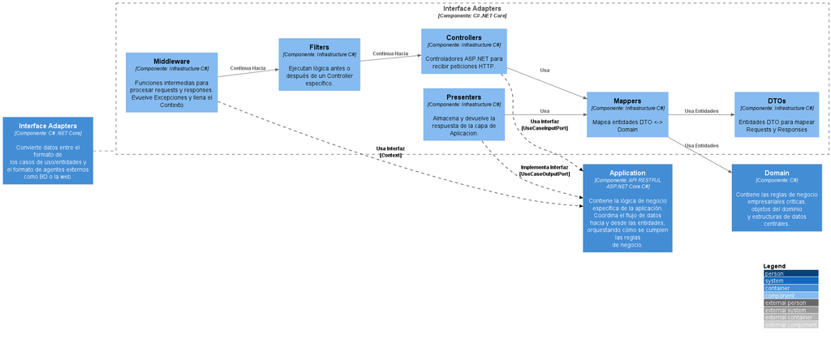

Diagrama C4 - Interface Adapters

## Análisis de Cada Componente

### `DTOs/`

#### `Requests/`

##### `CreateAnimalRequest.cs`

```csharp
namespace InterfaceAdapters.DTOs.Requests;

// Lo que recibe el API (HTTP)
public class CreateAnimalRequest
{
    public string Name { get; set; } = default!;
    public DateTime BirthDate { get; set; }
}
```

#### `Responses/`

##### `AnimalResponse.cs`

```csharp
namespace InterfaceAdapters.DTOs.Responses;

// Lo que devuelve el API
public class AnimalResponse
{
    public Guid Id { get; set; }
    public string Name { get; set; } = default!;
}
```

### `Mappers/`

#### `AnimalMapper.cs`

```csharp
using Application.Modules.Animals.UseCases.CreateAnimal;
using InterfaceAdapters.DTOs.Requests;

namespace InterfaceAdapters.Mappers;

public static class AnimalMapper
{
    // HTTP → Application
    public static CreateAnimalCommand ToCommand(CreateAnimalRequest request)
    {
        return new CreateAnimalCommand
        {
            Name = request.Name,
            BirthDate = request.BirthDate
        };
    }
}
```

### `Presenters/`

#### `CreateAnimalPresenter.cs`

```csharp
using Application.Modules.Animals.UseCases.CreateAnimal;
using InterfaceAdapters.DTOs.Responses;

namespace InterfaceAdapters.Presenters;

// Implementa OutputPort
public class CreateAnimalPresenter : ICreateAnimalOutputPort
{
    public AnimalResponse? Response { get; private set; }

    public Task Ok(CreateAnimalOutput output)
    {
        Response = new AnimalResponse
        {
            Id = output.Id,
            Name = output.Name
        };

        return Task.CompletedTask;
    }
}
```

### `Controllers/`

#### `AnimalsController.cs`

```csharp
using Microsoft.AspNetCore.Mvc;
using InterfaceAdapters.DTOs.Requests;
using InterfaceAdapters.Mappers;
using InterfaceAdapters.Presenters;
using Application.Modules.Animals.UseCases.CreateAnimal;

namespace InterfaceAdapters.Controllers;

[ApiController]
[Route("api/[controller]")]
public class AnimalsController : ControllerBase
{
    private readonly ICreateAnimalInputPort _inputPort;
    private readonly CreateAnimalPresenter _presenter;

    public AnimalsController(
        ICreateAnimalInputPort inputPort,
        CreateAnimalPresenter presenter)
    {
        _inputPort = inputPort;
        _presenter = presenter;
    }

    [HttpPost]
    public async Task<IActionResult> Create(CreateAnimalRequest request)
    {
        // 1. Mapear request → command
        var command = AnimalMapper.ToCommand(request);

        // 2. Ejecutar caso de uso
        await _inputPort.Handle(command);

        // 3. Devolver respuesta desde presenter
        return Ok(_presenter.Response);
    }
}
```

### `Middleware/`

#### `ExceptionHandlingMiddleware.cs`

```csharp
namespace InterfaceAdapters.Middleware;

public class ExceptionHandlingMiddleware
{
    private readonly RequestDelegate _next;

    public ExceptionHandlingMiddleware(RequestDelegate next)
    {
        _next = next;
    }

    public async Task InvokeAsync(HttpContext context)
    {
        try
        {
            await _next(context);
        }
        catch (Exception ex)
        {
            context.Response.StatusCode = 500;

            await context.Response.WriteAsJsonAsync(new
            {
                error = ex.Message
            });
        }
    }
}
```

#### `TenantResolutionMiddleware.cs`

Se encarga de resolver el Tenant en cada request HTTP, usando el `Context` proporcionado por `Infrastructure`.

```csharp
using Application.Common.Gateway.Context;

namespace InterfaceAdapters.Middleware;

public class TenantResolutionMiddleware
{
    private readonly RequestDelegate _next;
    private readonly string _baseDomain;

    public TenantResolutionMiddleware(
        RequestDelegate next,
        IConfiguration config)
    {
        _next = next;
        _baseDomain = config["MultiTenant:BaseDomain"]!;
    }

    public async Task InvokeAsync(
        HttpContext context,
        ITenantStore tenantStore,
        ITenantContext tenantContext)
    {
        // 1. Obtener host (subdominio)
        var host = context.Request.Host.Host;

        var slug = ExtractSlug(host);

        if (slug == null)
        {
            context.Response.StatusCode = 404;
            await context.Response.WriteAsync("Tenant no encontrado");
            return;
        }

        // 2. Buscar tenant (Infrastructure)
        var tenant = await tenantStore.GetBySlugAsync(slug);

        if (tenant == null)
        {
            context.Response.StatusCode = 404;
            await context.Response.WriteAsync("Tenant inválido");
            return;
        }

        // 3. Guardar en contexto (clave 🔥)
        ((TenantContext)tenantContext)
            .SetTenant(tenant.Id, tenant.DatabaseName);

        // 4. Continuar pipeline
        await _next(context);
    }

    private string? ExtractSlug(string host)
    {
        if (!host.EndsWith("." + _baseDomain))
            return null;

        return host[..^(_baseDomain.Length + 1)];
    }
}
```

### `Filters/`

#### `ValidationFilter.cs`

Esta clase válida automáticamente modelos HTTP o DTO’s antes de llegar al `Controller`.

```csharp
using Microsoft.AspNetCore.Mvc;
using Microsoft.AspNetCore.Mvc.Filters;

namespace InterfaceAdapters.Filters;

public class ValidationFilter : IActionFilter
{
    public void OnActionExecuting(ActionExecutingContext context)
    {
        // Aqui valida que se cmplan las anotaciones en el DTO
        // como [Required], [Length], etc.
        // antes de llegar al Controller
        if (!context.ModelState.IsValid)
        {
            context.Result = new BadRequestObjectResult(context.ModelState);
        }
    }

    public void OnActionExecuted(ActionExecutedContext context) { }
}
```

# VII. `Infrastructure` Layer

```bash
Infrastructure/
 ├── Persistence/
 │     ├── TenantCatalogDb.cs
 │     ├── GanaderiaDbContext.cs
 │     │
 │     ├── Entities/
 │     │     ├── ProductEntity.cs
 │     │     ├── AnimalEntity.cs
 │     │     ├── AppSettingEntity.cs
 │     │     └── FormFieldEntity.cs
 │     │
 │     ├── Mappers/
 │     │     ├── ProductMapper.cs
 │     │     └── AnimalMapper.cs
 │     │
 │     ├── Configurations/
 │     │     └── (Fluent API EF Core)
 │     │
 │     └── Repositories/
 │           ├── ProductRepository.cs
 │           └── AnimalRepository.cs
 │
 ├── Tenant/
 │     ├── ITenantDbContextFactory.cs
 │     ├── TenantDbContextFactory.cs
 │     ├── TenantContext.cs
 │     ├── ITenantStore.cs
 │     ├── TenantInfo.cs
 │     ├── TenantStore.cs
 │     └── TenantProvisioningService.cs
 │
 ├── Configuration/
 │     └── ConfigurationService.cs
 │
 ├── Features/
 │     └── FeatureService.cs
 │
 ├── Rules/
 │     └── RuleEngineService.cs
 │
 ├── Caching/
 │     └── AppCacheService.cs
 │
 ├── Context/
 │     └── RequestContext.cs
 │
 ├── Identity/
 │     └── CurrentUserService.cs
 │
 ├── Auditing/
 │     └── AuditSaveChangesInterceptor.cs
 │
 ├── Time/
 │     └── DateTimeProvider.cs
 │
 └── External/
       ├── SenasaClient.cs
       ├── WhatsAppService.cs
       └── PowerBIExporter.cs
```

## Diagrama C4

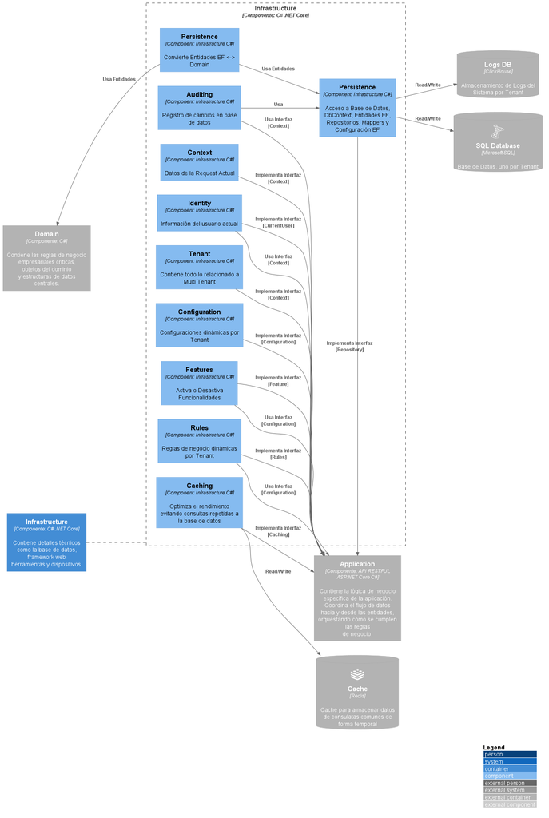

## Análisis de Cada Componente

### `Persistence/`

#### `GanaderiaDbContext.cs`

Se encarga de definir la conexión con la base de datos.

```csharp
// Infrastructure/
// Persistence/GanaderiaDbContext.cs
using Microsoft.EntityFrameworkCore;
using Infrastructure.Persistence.Entities;

namespace Infrastructure.Persistence;

public class GanaderiaDbContext : DbContext
{
    // Registra la Clase CowEntity como Entity
    public DbSet<CowEntity> Cows => Set<CowEntity>();

    public GanaderiaDbContext(DbContextOptions<GanaderiaDbContext> options,
    AuditSaveChangesInterceptor audit)
        : base(options)
        {
            _audit = audit;
        }

    protected override void OnConfiguring(DbContextOptionsBuilder optionsBuilder)
    {
        // Aquí se registra el interceptor para la auditoria en BD
        optionsBuilder.AddInterceptors(_audit);
    }

    protected override void OnModelCreating(ModelBuilder modelBuilder)
    {
        // Aplica configuración Fluent API
        modelBuilder.ApplyConfigurationsFromAssembly(typeof(GanaderiaDbContext).Assembly);
    }
}
```

#### `TenantCatalogDb.cs`

Este se diferencia del Context anterior ya que este Context sirve para guardar la informacion de un tenant.

```csharp
// Infrastructure/
// Persistence/TenantCatalogDb.cs
using Microsoft.EntityFrameworkCore;

namespace Infrastructure.Persistence;

public class TenantCatalogDb : DbContext
{
    public DbSet<TenantEntity> Tenants => Set<TenantEntity>();

    public TenantCatalogDb(DbContextOptions<TenantCatalogDb> options)
        : base(options) { }
}

// Entidad ORM
public class TenantEntity
{
    public Guid Id { get; set; }
    public string Slug { get; set; } = default!;
    public string DatabaseName { get; set; } = default!;
    public bool IsActive { get; set; }
}
```

#### `Entities/`

##### `CowEntity.cs`

```csharp
namespace Infrastructure.Persistence.Entities;

// Entidad de base de datos (NO es la del dominio)
public class CowEntity
{
    public Guid Id { get; set; }
    public string Name { get; set; } = default!;
    public DateTime BirthDate { get; set; }
}
```

#### `Mappers/`

##### `CowMapper.cs`

Esta clase se encargará de mapear las entidades de dominio a las entidades ORM y viceversa.

```csharp
using Domain.Entities;
using Infrastructure.Persistence.Entities;

namespace Infrastructure.Persistence.Mappers;

public static class CowMapper
{
    // Domain → Entity
    public static CowEntity ToEntity(Animal animal)
    {
        return new CowEntity
        {
            Id = animal.Id,
            Name = animal.Name,
            BirthDate = animal.BirthDate
        };
    }

    // Entity → Domain
    public static Animal ToDomain(CowEntity entity)
    {
        return new Animal(entity.Id, entity.Name, entity.BirthDate);
    }
}
```

#### `Configurations/`

Aqui se encuentran las clases que se encargan de configurar las Entidades ORM, permitendo añadir restricciones (nullable, unique, mex lenght, etc.), relaciones (1:1 , 1:n , n:m), indices, etc.

##### `CowConfiguration.cs`

```csharp
using Microsoft.EntityFrameworkCore;
using Microsoft.EntityFrameworkCore.Metadata.Builders;
using Infrastructure.Persistence.Entities;

namespace Infrastructure.Persistence.Configurations;

public class CowConfiguration : IEntityTypeConfiguration<CowEntity>
{
    public void Configure(EntityTypeBuilder<CowEntity> builder)
    {
        // Nombre de tabla en BD
        builder.ToTable("Cows");

        // Definir llave primaria
        builder.HasKey(x => x.Id);

        // Añadir restricciones a campo Name
        builder.Property(x => x.Name)
            .IsRequired()
            .HasMaxLength(100);

        // Añadir restricciones a campo BirthDate
        builder.Property(x => x.BirthDate)
            .IsRequired();
    }
}
```

#### `Repositories/`

Los repositorios nos permitirán interactuar con nuestros datos almacenados en la base de datos por medio de código o consultas `Raw SQL`, Recuerda que este repositorio implementa la Interfaz definida en Application:

##### `AnimalRepository.cs`

```csharp
using Domain.Entities;
using Application.Modules.Animals.Interfaces;
using Infrastructure.Persistence.Mappers;

namespace Infrastructure.Persistence.Repositories;

// Implementa interfaz de Application
public class AnimalRepository : IAnimalRepository
{
    // Se obtiene DbContext del Tenant actual
    private readonly ITenantDbContextFactory _factory;

    public AnimalRepository(ITenantDbContextFactory factory)
    {
        _factory = factory;
    }

    public async Task AddAsync(Animal animal)
    {
        using var db = _factory.CreateDbContext();

        var entity = CowMapper.ToEntity(animal);

        db.Cows.Add(entity);

        await db.SaveChangesAsync();
    }

    public async Task<List<Animal>> GetAllAsync()
    {
        using var db = _factory.CreateDbContext();

        var entities = db.Cows.ToList();

        return entities.Select(CowMapper.ToDomain).ToList();
    }
}
```

### `Tenant/`

#### `ITenantDbContextFactory.cs`

Interfaz para implementar patron Factory, se usará para llamar al `DbContext` correcto sin tener que cambiar la dependencia cada vez.

```csharp
using Infrastructure.Persistence;

public interface ITenantDbContextFactory
{
    GanaderiaDbContext CreateDbContext();
}
```

#### `TenantDbContextFactory.cs`

Implementa la interfaz `ITenantDbContextFactory`, y será usado para conectarse a la base de datos correcta cuando un usuario ingrese.

```csharp
using Microsoft.EntityFrameworkCore;
using Microsoft.Extensions.Configuration;
using Infrastructure.Persistence;
using Application.Common.Gateway.Context;

namespace Infrastructure.Tenant;

public class TenantDbContextFactory : ITenantDbContextFactory
{
    // Necesitamos la info del Tenant para conectarnos a la BD
    // correcta
    private readonly ITenantContext _tenant;
    private readonly IConfiguration _config;

    public TenantDbContextFactory(ITenantContext tenant, IConfiguration config)
    {
        _tenant = tenant;
        _config = config;
    }

    public GanaderiaDbContext CreateDbContext()
    {
        var template = _config.GetConnectionString("TenantTemplate")!;
        var conn = template.Replace("{DATABASE}", _tenant.DatabaseName);

        var options = new DbContextOptionsBuilder<GanaderiaDbContext>()
            .UseSqlServer(conn)
            .Options;

        return new GanaderiaDbContext(options);
    }
}
```

#### `TenantContext.cs`

Esta clase se usará como almacén, para guardar los datos del tenant actual y poder acceder después a ellos cuando se requiera, por ejemplo, cuando se necesite conectar a una determinada base de datos.

```csharp
using Application.Common.Gateway.Context;

namespace Infrastructure.Tenant;

public class TenantContext : ITenantContext
{
    public Guid TenantId { get; private set; }
    public string DatabaseName { get; private set; } = "";

    public void SetTenant(Guid id, string dbName)
    {
        TenantId = id;
        DatabaseName = dbName;
    }
}
```

#### `ITenantStore.cs`

```csharp
namespace Infrastructure.Tenant;

public interface ITenantStore
{
    Task<TenantInfo?> GetBySlugAsync(string slug);
}
```

#### `TenantInfo.cs`

Este `DTO` servirá para mapear la información del `Tenant` actual obtenido por medio de la clase `TenantStore.cs`.

```csharp
namespace Infrastructure.Tenant;

// DTO interno de infraestructura
public class TenantInfo
{
    public Guid Id { get; set; }
    public string Slug { get; set; } = default!;
    public string DatabaseName { get; set; } = default!;
    public bool IsActive { get; set; }
}
```

#### `TenantStore.cs`

Sirve para obtener la información del `Tenant`, ya sea por base de datos o cache.

```csharp
using Microsoft.EntityFrameworkCore;
using Microsoft.Extensions.Caching.Memory;
using Infrastructure.Persistence;

namespace Infrastructure.Tenant;

public class TenantStore : ITenantStore
{
    private readonly TenantCatalogDb _db;
    private readonly IMemoryCache _cache;

    public TenantStore(TenantCatalogDb db, IMemoryCache cache)
    {
        _db = db;
        _cache = cache;
    }

    public async Task<TenantInfo?> GetBySlugAsync(string slug)
    {
        var cacheKey = $"tenant:{slug}";

        // Intenta cache
        if (_cache.TryGetValue(cacheKey, out TenantInfo cached))
            return cached;

        // Busca en DB
        var tenant = await _db.Tenants
            .AsNoTracking()
            .FirstOrDefaultAsync(t => t.Slug == slug);

        if (tenant == null || !tenant.IsActive)
            return null;

        // Almacenar info del Tenant
        // en DTO
        var result = new TenantInfo
        {
            Id = tenant.Id,
            Slug = tenant.Slug,
            DatabaseName = tenant.DatabaseName,
            IsActive = tenant.IsActive
        };

        // Guarda en cache
        _cache.Set(cacheKey, result, TimeSpan.FromMinutes(5));

        return result;
    }
}
```

#### `TenantProvisioningService.cs`

Esta clase servirá para crear un nuevo Tenant.

```csharp
using Microsoft.EntityFrameworkCore;
using Microsoft.Extensions.Configuration;
using Infrastructure.Persistence;

namespace Infrastructure.Tenant;

public class TenantProvisioningService
{
    private readonly TenantCatalogDb _catalogDb;
    private readonly IConfiguration _config;

    public TenantProvisioningService(
        TenantCatalogDb catalogDb,
        IConfiguration config)
    {
        _catalogDb = catalogDb;
        _config = config;
    }

    public async Task ProvisionAsync(CreateTenantDto dto)
    {
        // Generar nombre de base de datos
        var dbName = $"Ganaderia_{dto.Slug.Replace("-", "_")}_Db";

        // Registrar Tenant en catálogo
        var tenant = new TenantEntity
        {
            Id = Guid.NewGuid(),
            Slug = dto.Slug,
            DatabaseName = dbName,
            IsActive = true
        };

        _catalogDb.Tenants.Add(tenant);
        await _catalogDb.SaveChangesAsync();

        // Crear DB dinámica
        var template = _config.GetConnectionString("TenantTemplate")!;
        var conn = template.Replace("{DATABASE}", dbName);

        var options = new DbContextOptionsBuilder<GanaderiaDbContext>()
            .UseSqlServer(conn)
            .Options;

        await using var db = new GanaderiaDbContext(options);

        // Aplicar migraciones automáticamente
        await db.Database.MigrateAsync();

        // Seed inicial (opcional)
        await SeedAsync(db);
    }

    private async Task SeedAsync(GanaderiaDbContext db)
    {
        if (!db.Cows.Any())
        {
            db.Cows.Add(new Persistence.Entities.CowEntity
            {
                Id = Guid.NewGuid(),
                Name = "Vaca Inicial",
                BirthDate = DateTime.UtcNow
            });

            await db.SaveChangesAsync();
        }
    }
}

// Este DTO servira para pasar los datos necesarios
// para la creacion del Tenant
// puede ir en InterfaceAdapters y luego mapearse hacia un DTO
// en Application donde habra un UseCase para crear el tenant
// Pero se debe crear un Gateway para poder interactuar con la clase
// sin romper la arquitectura
// por simplicidad se puede mantener en /Tenant/CreateTenantDto.cs
public class CreateTenantDto
{
    public string Slug { get; set; } = default!;
    public string DisplayName { get; set; } = default!;
    public string Email { get; set; } = default!;
}
```

### `Configuration/`

#### `ConfigurationService.cs`

Sirve para obtener las configuraciones actuales que cada Tenant pueda tener (esto se guarda en BD), cosas como Días Estándar de Celo, Campos Obligatorios, Idioma, Unidades (litros o kg), Litros de Leche mínima, etc. Los resultados pueden ser usados por la capa de `Application`.

```csharp
using Application.Common.Gateway.Configuration;

namespace Infrastructure.Configuration;

public class ConfigurationService : IConfigurationService
{
    private readonly ITenantDbContextFactory _factory;

    public ConfigurationService(ITenantDbContextFactory factory)
    {
        _factory = factory;
    }

    public async Task<T?> GetValueAsync<T>(string key)
    {
        using var db = _factory.CreateDbContext();

        var setting = db.Set<AppSettingEntity>()
            .AsNoTracking()
            .FirstOrDefault(x => x.Key == key);

        if (setting == null)
            return default;

        return (T)Convert.ChangeType(setting.Value, typeof(T));
    }
}
```

### `Features/`

#### `FeatureService.cs`

Esto controla features activas o inactivas por tenant, por ejemplo, un Cliente A puede tener un modulo activado y otro cliente B no. Devuelve un booleano y es usada por la capa de `Application`.

```csharp
using Application.Common.Gateway.Features;
using Microsoft.EntityFrameworkCore;

namespace Infrastructure.Features;

public class FeatureService : IFeatureService
{
    private readonly ITenantDbContextFactory _factory;

    public FeatureService(ITenantDbContextFactory factory)
    {
        _factory = factory;
    }

    public async Task<bool> IsEnabledAsync(string feature)
    {
        using var db = _factory.CreateDbContext();

        var result = await db.Set<FeatureEntity>()
            .AsNoTracking()
            .FirstOrDefaultAsync(f => f.Name == feature);

        return result?.IsEnabled ?? false;
    }
}

// Debe tener su Entity ORM en EF Core
public class FeatureEntity
{
    public Guid Id { get; set; }
    public string Name { get; set; } = default!;
    public bool IsEnabled { get; set; }
}
```

### `Rules/`

#### `RuleEngineService.cs`

Esto se diferencia de `Configuration`, ya que aquí se ejecutan reglas de negocio dinámicas, las reglas o lógica pueden guardarse en base de datos o escribirse como código. Se puede implementar usando librerías como `NRules`.

Se pueden usar `Configuration` y `Rules` en conjunto, una para obtener la configuración establecida en el Tenant y otra para evaluar si los datos que se ingresan son correctos. Por ejemplo, si tenemos una configuración `milk.min.liters` que nos diga que cantidad de leche se considera baja y una regla `milk.low.production` que se encargue de evaluar si el input del usuario es realmente bajo o no según lo que dice el valor de la configuración.

```csharp
using Application.Common.Gateway.Rules;

namespace Infrastructure.Rules;

public class RuleEngineService : IRuleEngineService
{
    public Task<bool> EvaluateAsync(string rule, object input)
    {
        // Por ejemplo aqui se evalua si la cantidad
        // de leche ingresada es bajo o no
        // devuelve true o false
        if (rule == "milk.low.production")
        {
            dynamic data = input;
            return Task.FromResult(data.Liters < 10);
        }

        return Task.FromResult(true);
    }
}
```

### `Caching/`

#### `AppCacheService.cs`

```csharp
using Microsoft.Extensions.Caching.Memory;
using Application.Common.Gateway.Caching;

namespace Infrastructure.Caching;

public class AppCacheService : IAppCacheService
{
    private readonly IMemoryCache _cache;

    public AppCacheService(IMemoryCache cache)
    {
        _cache = cache;
    }

    public async Task<T> GetOrCreateAsync<T>(
        string key,
        Func<Task<T>> factory,
        TimeSpan expiration)
    {
        if (_cache.TryGetValue(key, out T value))
            return value;

        value = await factory();

        _cache.Set(key, value, expiration);

        return value;
    }
}
```

### `Context/`

#### `RequestContext.cs`

```csharp
using Application.Common.Gateway.Context;
using Microsoft.AspNetCore.Http;
using System.Security.Claims;

namespace Infrastructure.Context;

public class RequestContext : IRequestContext
{
    private readonly IHttpContextAccessor _http;

    public RequestContext(IHttpContextAccessor http)
    {
        _http = http;
    }

    public string? UserId =>
        _http.HttpContext?.User?.FindFirst("sub")?.Value;

    public string? UserEmail =>
        _http.HttpContext?.User?.FindFirst(ClaimTypes.Email)?.Value;

    public string? CorrelationId =>
        _http.HttpContext?.TraceIdentifier;

    public string? Path =>
        _http.HttpContext?.Request?.Path.Value;
}
```

### `Identity/`

#### `CurrentUserService.cs`

```csharp
using Application.Common.Gateway.Identity;
using Application.Common.Gateway.Context;

namespace Infrastructure.Identity;

public class CurrentUserService : ICurrentUserService
{
    private readonly IRequestContext _ctx;

    public CurrentUserService(IRequestContext ctx)
    {
        _ctx = ctx;
    }

    public string? UserId => _ctx.UserId;
}
```

### `Auditing/`

#### `AuditSaveChangesInterceptor.cs`

```csharp
using Microsoft.EntityFrameworkCore.Diagnostics;
using Microsoft.EntityFrameworkCore;
using Application.Common.Gateway.Context;

namespace Infrastructure.Auditing;

public class AuditSaveChangesInterceptor : SaveChangesInterceptor
{
    private readonly ITenantContext _tenant;
    private readonly IRequestContext _request;

    public AuditSaveChangesInterceptor(
        ITenantContext tenant,
        IRequestContext request)
    {
        _tenant = tenant;
        _request = request;
    }

    public override async ValueTask<InterceptionResult<int>> SavingChangesAsync(
        DbContextEventData eventData,
        InterceptionResult<int> result,
        CancellationToken cancellationToken = default)
    {
        var ctx = eventData.Context!;

        foreach (var entry in ctx.ChangeTracker.Entries())
        {
            if (entry.State == EntityState.Added ||
            entry.State == EntityState.Modified ||
            entry.State == EntityState.Deleted)
            {
                // Evitar auditar la propia tabla de auditoria
                // evitando asi bucles
                if (entry.Entity is AuditEntry)
                    continue;

                var audit = new AuditEntry
                {
                    TenantId = _tenant.TenantId,
                    UserId = _request.UserId,
                    Entity = entry.Entity.GetType().Name,
                    Operation = entry.State.ToString(),
                    Timestamp = DateTime.UtcNow
                };

                context.Set<AuditEntry>().Add(audit);
            }
        }

        return await base.SavingChangesAsync(eventData, result, cancellationToken);
    }
}
```

### `Time/`

#### `DateTimeProvider.cs`

```csharp
namespace Infrastructure.Time;

public class DateTimeProvider : IDateTimeProvider
{
    public DateTime UtcNow => DateTime.UtcNow;
}
```

### `External/`

#### `SenasaClient.cs`

```csharp
namespace Infrastructure.External;

public class SenasaClient
{
    private readonly HttpClient _http;

    public SenasaClient(HttpClient http)
    {
        _http = http;
    }

    public async Task SendAsync(object data)
    {
        await _http.PostAsJsonAsync("/senasa", data);
    }
}
```

# 🔄 FLUJO COMPLETO

```
HTTP Request
 → Middleware (Tenant)
 → Controller
 → UseCase (Application)
 → Domain
 → Repository (Infrastructure)
 → DB
```

# 🎯 CONCLUSIÓN

✔ Arquitectura desacoplada ✔ Multi-tenant ✔ Altamente configurable ✔ Escalable